# Open habitats increase vulnerability of amphibian tadpoles to climate warming across latitude

Supplementary Information

Nicholas C. Wu[^1]

20/01/2023

[GitHub Repository](https://github.com/nicholaswunz/tadpole-thermal-tolerance)  
The Rmarkdown file can be downloaded from the *Code* drop down menu (top right).[^2]

This supplementary file contains the *R* workflow for processing and analysing the raw data, and creating figures for the manuscript ID: GEB-2022-0268 titled “**Open habitats increase vulnerability of amphibian tadpoles to climate warming across latitude**”.

# 1 Pond thermodynamic model

Water temperature is computed based on a heat budget considering longwave radiation, solar heating, and standard bulk aerodynamic flux parameterizations for sensible and latent heat (Mitchell et al., 2012). The budget is driven by fundamental meteorological conditions provided in the microclimate model of *NicheMapR* (Kearney and Porter, 2017), specific to each site, with the Equation (1.1).

$$\begin{equation}
(Lp_w\ c_p)\ \ \frac{dT_w}{dt}=p_w\ c_p\ (I\ T_i-O\ T_w+R\ T_{sky}A_L\ )+(H-E-S+\phi_{LW} +\phi_{SW})\ A_L
\tag{1.1}
\end{equation}$$

where $T_w$ is the lake temperature, $T_i$ is the inflow temperature, $T_{sky}$ is the air temperature (all in °K), $p_w$ is the density of water (kg m<sup>-3</sup>), $c_p$ is the specific heat capacity of water (J kg<sup>-1</sup> K<sup>-1</sup>), $L$ is the lake volume (m<sup>-3</sup>) and $I$, $O$, and ($A_L\ R$) are the inflow, outflow and rainfall volume fluxes respectively (m<sup>-3</sup> d<sup>-1</sup>), where $A_L$ is the lake surface area (m<sup>-2</sup>) used to multiply the rainfall depth (m d<sup>-1</sup>). $H$ (1.2), $E$ (1.3), $S$ (1.4) are heat fluxes (W m<sup>-2</sup>) for sensible heat, evaporative and soil heat conduction, respectively, calculated according to:

$$\begin{equation}
H=p_a\ c_p\ C_H\ u_2 (T_{sky}-T_w)
\tag{1.2}
\end{equation}$$

$$\begin{equation}
E=p_a\ \lambda\ C_E\ u_2\ (e_s-e_a)
\tag{1.3}
\end{equation}$$

$$\begin{equation}
S=\frac{C_S}{z_s}(T_s-T_w)
\tag{1.4}
\end{equation}$$

where $C_H$ and $C_E$ are bulk transfer coefficients for sensible and latent heat respectively (-), $\lambda$ is the latent heat of vaporization (J kg<sup>-1</sup>), $p_a$ is the density of air (kg m<sup>-3</sup>), and $C_S$ is the diffusivity of heat into the soil below the water (W m<sup>-1</sup> K<sup>-1</sup>), and $z_s$ is the active soil depth over which heat diffusion occurs. $\phi_{LW}$ (1.5) is the new longwave radiation (W m<sup>-2</sup>) and $\phi_{SW}$ (1.6) is the solar insolation (W m<sup>-2</sup>), calculated from:

$$\begin{equation}
\phi_{LW}=\varepsilon_a\ \sigma(T_{sky})^4-\varepsilon_w\ \sigma(T_w)^4
\tag{1.5}
\end{equation}$$

$$\begin{equation}
\phi_{SW}=(1-\alpha)\ {\hat{\phi}}_{SW}\bigg[\frac{A_L}{A_{MAX}}\ k_s \bigg]
\tag{1.6}
\end{equation}$$

where $\varepsilon$ is the emissivity of air or water, $\sigma$ is the Stefan-Boltzmann constant, $\alpha$ is the shortwave radiation albedo, ${\hat{\phi}}_{SW}$ is the incident solar radiation above vegetation (W m<sup>-2</sup>). The last term (1.6) accounts for the effect of wetland vegetation shading on the incident solar intensity, with $k_s$ defined as a constant to increase the shading effect, and $A_{MAX}$ is the maximum area of inundation extent (m<sup>-2</sup>). In *NicheMapR*, assumed values for $C_S$, $C_H$, $C_E$, $\varepsilon_a$, $k_s$ were 0.5, 0.0013, 0.0013, 0.99 and 0.25, respectively.

# 2 Dataset

## 2.1 Prepare raw data for analysis

The raw data for analysis is available on [GitHub](https://github.com/nicholaswunz/tadpole-thermal-tolerance). This section is the import and clean the raw data for analysis.

```r
# Clean raw data
clean_dat <- read.csv("https://raw.githubusercontent.com/nicholaswunz/tadpole-thermal-tolerance/main/data/raw_data.csv", na.strings = c("" , "NA" ), stringsAsFactors = TRUE) %>%
  dplyr::mutate(WT           = CTmax - Tmax,
                region       = factor(region, levels = c('Subtropics', 'Temperate')),
                country      = as.factor(country),
                habitat      = as.factor(collection_habitat),
                species_tree = gsub(" ", "_", species))

# Summarise data by group
summary_dat <- as.data.frame(clean_dat %>%
  dplyr::group_by(region, country, habitat, family, species, sp_abbr, species_tree, breeding_habitat, citation) %>%
  dplyr::summarise(lon        = mean(lon),
                   lat        = mean(lat),
                   CTmax_mean = mean(CTmax),
                   CTmax_SD   = sd(CTmax),
                   Tmax       = mean(Tmax),
                   WT_mean    = mean(WT),
                   WT_SD      = sd(WT),
                   n          = n(),
                   month_start = mean(month_start),
                   month_end   = mean(month_end))) %>%
  dplyr::relocate(c(breeding_habitat, citation), .after = last_col())
```

## 2.2 Species data summary

### Table S1a

**Table S1.** List of species included in the study with their sample size (*n*), mean ± s.d. critical thermal maxima (CT<sub>max</sub>), maximum environmental water temperature (T<sub>max</sub>), habitat type based on collection site, and spatial coordinates (latitude and longitude as decimal degree).

| Species (abbreviation) | n | CT<sub>max</sub> ± s.d. (°C) | T<sub>max</sub> (°C) | Collection habitat | Latitude | Longitude |
| --- | --- | --- | --- | --- | --- | --- |
| *Bufo bankorensis* (BB) | 15 | 37.54±0.40 | 18.79 | Forest | 23.919 | 120.883 |
| *Microhyla heymonsi* (MH) | 15 | 37.44±0.58 | 23.90 | Forest | 23.919 | 120.883 |
| *Odorrana swinhoana* (OS) | 30 | 35.85±0.51 | 23.55 | Forest | 23.988 | 121.129 |
| *Kurixalus berylliniris* (KBE) | 16 | 33.54±0.73 | 24.74 | Forest | 22.803 | 121.051 |
| *Kurixalus eiffingeri* (KE) | 15 | 31.05±1.60 | 25.01 | Forest | 23.690 | 120.791 |
| *Polypedates braueri* (PB) | 12 | 40.17±0.32 | 26.77 | Forest | 23.889 | 120.891 |
| *Zhangixalus moltrechti* (ZM) | 15 | 37.36±0.52 | 24.17 | Forest | 23.889 | 120.891 |
| *Duttaphrynus melanostictus* (DM) | 15 | 41.41±0.22 | 35.12 | Open | 24.181 | 120.609 |
| *Fejervarya limnocharis* (FL) | 20 | 41.50±0.93 | 30.12 | Open | 24.863 | 121.550 |
| *Hyla chinensis* (HC) | 12 | 38.23±0.39 | 29.14 | Open | 24.594 | 120.999 |
| *Microhyla fissipes* (MF) | 19 | 39.71±0.77 | 29.34 | Open | 24.890 | 121.567 |
| *Micryletta steinegeri* (MS) | 12 | 37.35±0.45 | 33.03 | Open | 23.836 | 120.748 |
| *Hylarana latouchii* (HL) | 12 | 37.52±0.37 | 21.34 | Open | 23.891 | 120.884 |
| *Rana longicrus* (RL) | 10 | 35.79±0.51 | 19.75 | Open | 25.191 | 121.590 |
| *Rana sauteri* (RS) | 14 | 32.44±1.14 | 24.89 | Open | 23.902 | 120.891 |
| *Buergeria choui* (BC) | 20 | 41.40±1.03 | 30.12 | Open | 24.863 | 121.550 |
| *Buergeria robusta* (BR) | 13 | 38.48±1.21 | 25.28 | Open | 23.879 | 120.887 |
| *Kurixalus idiootocus* (KI) | 10 | 37.40±1.35 | 30.00 | Open | 23.914 | 120.896 |
| *Rana pirica* (RP) | 8 | 33.91±1.48 | 14.50 | Forest | 42.595 | 141.281 |
| *Bufo japonicus formosus* (BJF) | 7 | 40.10±0.48 | 32.50 | Open | 43.143 | 141.204 |
| *Glandirana rugosa* (GR) | 10 | 39.15±0.35 | 32.50 | Open | 43.002 | 141.181 |
| *Bombina orientalis* (BO) | 30 | 39.93±0.67 | 23.29 | Forest | 36.813 | 128.054 |
| *Bufo gargarizans* (BG) | 48 | 38.04±0.61 | 17.95 | Forest | 36.491 | 127.197 |
| *Rana coreana* (RC) | 42 | 36.02±1.63 | 16.99 | Forest | 36.718 | 126.618 |
| *Rana uenoi* (RU) | 12 | 38.23±0.68 | 21.95 | Forest | 36.812 | 128.052 |
| *Dryophytes japonicus* (DJ) | 36 | 40.91±1.52 | 32.50 | Open | 37.599 | 126.892 |
| *Kaloula borealis* (KBO) | 6 | 42.65±0.26 | 36.84 | Open | 37.521 | 126.880 |
| *Pelophylax nigromaculatus* (PN) | 8 | 39.50±3.61 | 32.50 | Open | 36.887 | 126.936 |
| *Glandirana emeljanovi* (GE) | 30 | 38.10±1.07 | 29.05 | Open | 37.832 | 127.558 |

- *Bufo gargarizans* was recently renamed to *Bufo schalinensis* (Othman et al., 2022).

### Table S1b

**Table S1.** Continuation of species summary with additional information on Family, and notes on the species typical breeding habitat based on the associated references. Species grouped as forest primarily breed in forest habitats. Species grouped as forest edge typically breed at the edges of forests (more exposure to sunlight). Species grouped as open primarily breed in open habitats. Species grouped as generalist typically breed in both forest and open habitats.

[output not shown]

- *Bufo gargarizans* was recently renamed to *Bufo schalinensis* (Othman et al., 2022).
- Reference list: Ambu et al. (2022), Chang et al. (2014), Hou et al. (2008), Hsu et al. (2012), Huang et al. (1996), Huang et al. (1997), Huang et al. (2004), Jang-Liaw and Lee (2009), Jung et al. (2013), Kam et al. (1995), Kuan and Lin (2011), Lai et al. (2007), Lin et al. (2012), Lin and Kam (2008), Matsui and Maeda (2018), Roh et al. (2014), Tominaga et al. (2015), Wu et al. (2016), Yang et al. (2001), Yoo et al. (2019).

# 3 Phylogeny

## 3.1 Species ascension gene number

**Table S2.** Accession number of genes of all species (ingroups and outgroups) in the analysis from the National Center for Biotechnology Information ([NCBI](https://www.ncbi.nlm.nih.gov/)).

| Species | 12S | 16S | COI | cytb |
| --- | --- | --- | --- | --- |
| **Ingroup** |  |  |  |  |
| *Bufo gargarizans* | DQ275350 | DQ275350 | DQ275350 | DQ275350 |
| *Bufo japonicus formosus* | LC061223 | LC061223 |  | AB713498 |
| *Bombina orientalis* | AY585338 | AY585338 | AY585338 | AY585338 |
| *Buergeria choui* | DQ283055 | DQ283055 | MH034165 | KC151119 |
| *Buergeria robusta* | AB530075 | AF026370 | GU244379 | JF802879 |
| *Bufo bankorensis* | AF160768 | AF160786 | HQ650558 | AB159260 |
| *Dryophytes japonicus* | AB303949 | AB303949 | AB303949 | AB303949 |
| *Duttaphrynus melanostictus* | AY458592 | AY458592 | AY458592 | AY458592 |
| *Fejervarya limnocharis* | AY158705 | AY158705 | AY158705 | AY158705 |
| *Glandirana emeljanovi* | NC_030211 | NC_030211 | NC_030211 | NC_030211 |
| *Glandirana rugosa* | KF771341 | KF771341 | JQ844517 | KF771341 |
| *Hyla chinensis* | AY458593 | AY458593 | AY458593 | AY458593 |
| *Hylarana latouchii* | KF771284 | AB058880 | JN700815 | EU034751 |
| *Kaloula borealis* | NC_020044 | NC_020044 | NC_020044 | NC_020044 |
| *Kurixalus berylliniris* |  | DQ468669 | DQ468677 |  |
| *Kurixalus eiffingeri* | AB933305 | AF026363 | DQ468680 |  |
| *Kurixalus idiootocus* | AB933306 | DQ468674 | DQ468682 | GQ204503 |
| *Microhyla fissipes* | AB201175 | AB201185 | KR087802 | AB201219 |
| *Microhyla heymonsi* | AY458596 | AY458596 | AY458596 | AY458596 |
| *Micryletta steinegeri* | AB634638 | AB634696 |  |  |
| *Odorrana swinhoana* | AB200929 | KF185045 | HQ650557 |  |
| *Pelophylax nigromaculatus* | KT878718 | KT878718 | KT878718 | KT878718 |
| *Polypedates braueri* | AB728016 | AB728003 | KR087860 |  |
| *Rana coreana* | NC_024548 | NC_024548 | NC_024548 | NC_024548 |
| *Rana longicrus* |  | AB058881 |  | JF939130 |
| *Rana pirica* | KX269184 | KX269184 | KX024946 | KX269331 |
| *Rana sauteri* | AB685767 | AB211495 |  | EU034956 |
| *Rana uenoi* | KX269177 | KX024885 | KX024945 | KX024969 |
| *Zhangixalus moltrechti* | AF458145 | DQ468676 | HQ650556 | U00710 |
| **Outgroup** |  |  |  |  |
| *Ascaphus truei* | X86225 | DQ283116 | AJ871087 | AF277330 |
| *Batrachuperus pinchonii* | AY916007 | DQ283340 | KM201393 | AY593142 |
| *Gyrinophilus porphyriticus* | EU336432 | DQ283255 | NC_006341 | NC_006341 |

## 3.2 Prepare phylogeny for analysis

This section is the import the phylogenetic tree (see phylogenetic reconstruction in main text) comprising of 29 species, match names with the data set, and create a correlation matrix for subsequent analysis.

```r
# Load phylogeny data
phylo_tree <- ape::read.tree("https://raw.githubusercontent.com/nicholaswunz/tadpole-thermal-tolerance/main/data/tree2021_12.nwk")

tree_tip_label <- phylo_tree$tip.label # extract tree tip names
species_list   <- unique(clean_dat$species_tree) # extract species name from main dataset
missing_sp     <- as.data.frame(setdiff(tree_tip_label, species_list)) # check what names from the dataset not found in phylo_tree
# Three outgroups in tree

pruned_tree    <- ape::drop.tip(phylo_tree, setdiff(phylo_tree$tip.label, species_list)) # prune phylo_tree to keep species from the main dataset

# check if lengths match for both data and tree
sp_n <- length(unique(pruned_tree$tip.label)) # 29
#length(unique(clean_dat$species_tree)) # 29

# Check for polytomies
#ape::is.binary(pruned_tree) # TRUE

# Compute branch lengths
pruned_tree_cal <- ape::compute.brlen(pruned_tree, method = "Grafen", power = 1)
#ape::is.ultrametric(pruned_tree_cal) # TRUE

# Create correlation matrix for analysis
phylo_cor <- vcv(pruned_tree_cal, cor = T)
```

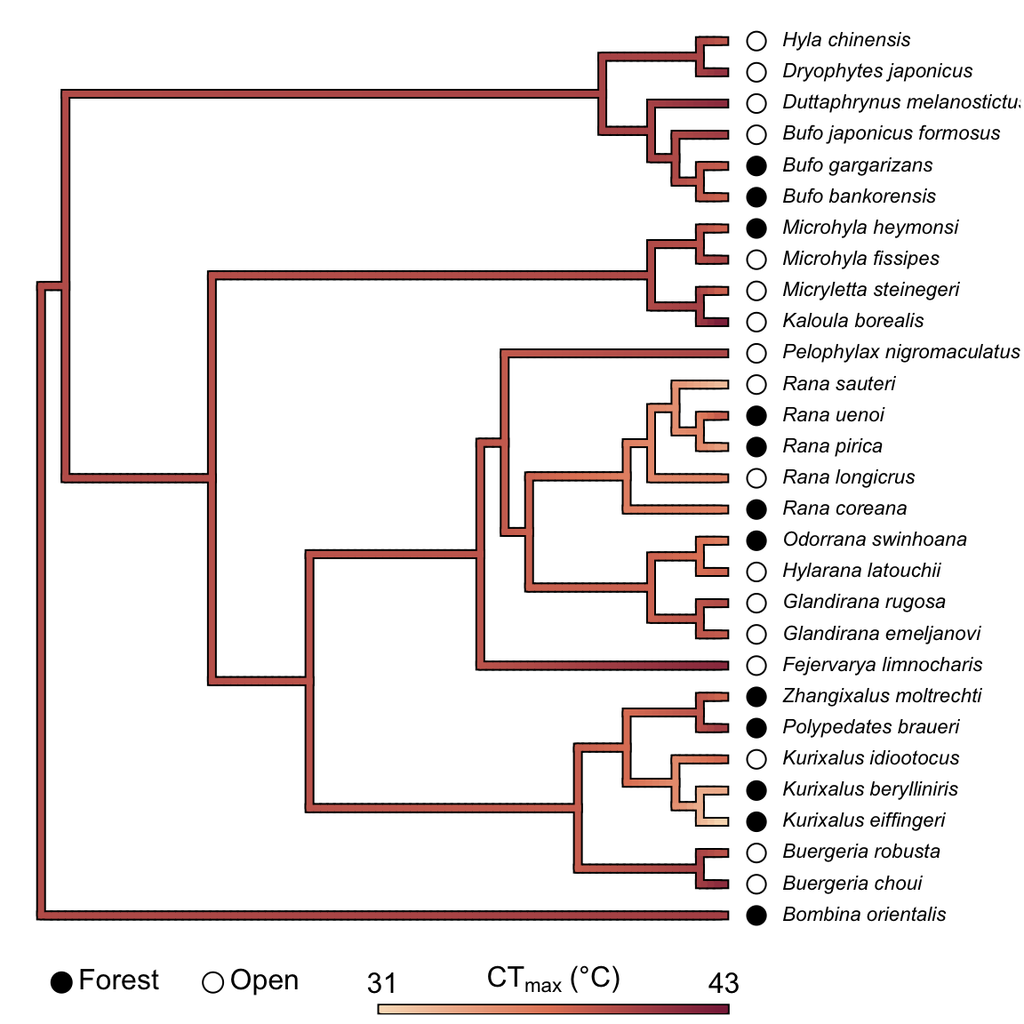

# 4 Microclimate models and future scenario

## 4.1 *NicheMapR* parameters

**Table S3.** Parameter values used to estimate pond temperature using *NicheMapR*. Parameters for which settings differ from default values are shown in **bold**. Default values for other parameters in the model remained.

[output not shown]

* textural soil properties for clay: depth (2.5, 7.5, 22.5, 45, 80, 150), bulk density 1.4 mg m$\\^3$, 90% clay, 0% silt, 10% sand.

## 4.2 Define soil parameters

Define soil parameters to enable construction of hypothetical water body in *NicheMapR*. Parameters modified presented in **Table S3**.

```r
# Define textural soil properties for clay
soilpro <- matrix(data = 0, nrow = 6, ncol = 5)
colnames(soilpro) <- c('depth', 'blkdens', 'clay', 'silt', 'sand')
soilpro <- as.data.frame(soilpro) %>%
  dplyr::mutate(depth   = c(2.5, 7.5, 22.5, 45, 80, 150),
                blkdens = 1.4, # bulk density (Mg/m3)
                clay    = 90, # % clay
                silt    = 0.0, # % silt
                sand    = 10) # % sand
DEP     <- c(0, 2, 5, 10, 15, 20, 30, 40, 50, 100) # Soil nodes (cm)

# Get hydraulic properties for given soil
soil.hydro  <- NicheMapR::pedotransfer(soilpro = soilpro, DEP = DEP)
PE <- soil.hydro$PE
BB <- soil.hydro$BB
BD <- soil.hydro$BD
KS <- soil.hydro$KS
BulkDensity <- BD[seq(1, 19, 2)]

rainmult  <- 10 # Rainfall multiplier to reflect catchment (1 will result in unadjusted rainfall)
maxpool   <- 500 # maximium pooling depth (mm), i.e. wetland depth
LAI       <- 0 # leaf area index (zero so no transpiration)
cap       <- 0 # do not simulate the organic cap layer
soilgrids <- 0 # don't use SoilGrids soil database for thermal properties
```

## 4.3 Simulate pond temperature

Run *NichemapR* to simulate pond temperatures under four hypothetical scenarios: (**a**) current climate with open habitat, (**b**) current climate with shaded habitat, (**c**) warming climate with open habitat, and (**d**) warming climate with shaded habitat.

```r
# Simulate dates for 2 years
dates <- NicheMapR::micro_global(nyear = 2)$dates

# Create loop for each coordinates
est_Tmax_open <- NULL
for( i in 1:nrow(summary_dat)){
  result <- data.frame(
    NicheMapR::micro_global(loc      = c(summary_dat$lon[i], summary_dat$lat[i]),
                            runshade = 0, minshade = 0, maxshade = 10, # shade parameters
                            PCTWET   = 100, # model surface soil wetness (%),
                            PE = PE, BB = BB, BD = BD, KS = KS, rainmult = rainmult,
                            maxpool = maxpool, LAI = LAI, cap = cap, soilgrids = soilgrids, # soil parameters to simulate pool
                            warm = 0, # current climate
                            nyear = 2,)$soil) %>% # extract soil parameters
    dplyr::mutate(dates = dates) %>%
    dplyr::filter(dates >= summary_dat$month_start[i] & dates <= summary_dat$month_end[i]) %>%
    dplyr::summarise(est_Tmax_open = max(D0cm))
  print(result)
  results_2 <- cbind(summary_dat$species[i], result)
  est_Tmax_open <- rbind(est_Tmax_open, results_2)
}

est_Tmax_shade <- NULL
for( i in 1:nrow(summary_dat)){
  result <- data.frame(
    NicheMapR::micro_global(loc      = c(summary_dat$lon[i], summary_dat$lat[i]),
                            runshade = 0, minshade = 95, maxshade = 100, # shade parameters
                            PCTWET   = 100, # model surface soil wetness (%),
                            PE = PE, BB = BB, BD = BD, KS = KS, rainmult = rainmult, maxpool = maxpool, LAI = LAI, cap = cap, soilgrids = soilgrids, # soil parameters to simulate pool
                            warm = 0, # current climate
                            nyear = 2)$soil) %>% # Extract soil parameters
    dplyr::mutate(dates = dates) %>%
    dplyr::filter(dates >= summary_dat$month_start[i] & dates <= summary_dat$month_end[i]) %>%
    dplyr::summarise(est_Tmax_shade = max(D0cm))
  print(result)
  est_Tmax_shade <- rbind(est_Tmax_shade, result)
}

est_Tmax_open_4C <- NULL
for( i in 1:nrow(summary_dat)){
  result <- data.frame(
    NicheMapR::micro_global(loc      = c(summary_dat$lon[i], summary_dat$lat[i]),
                            runshade = 0, minshade = 0, maxshade = 10, # shade parameters
                            PCTWET   = 100, # model surface soil wetness (%),
                            PE = PE, BB = BB, BD = BD, KS = KS, rainmult = rainmult, maxpool = maxpool, LAI = LAI, cap = cap, soilgrids = soilgrids, # soil parameters to simulate pool
                            warm = 4, # future climate
                            nyear = 2,)$soil) %>% # extract soil parameters
    dplyr::mutate(dates = dates) %>%
    dplyr::filter(dates >= summary_dat$month_start[i] & dates <= summary_dat$month_end[i]) %>%
    dplyr::summarise(est_Tmax_open_4C = max(D0cm))
  print(result)
  est_Tmax_open_4C <- rbind(est_Tmax_open_4C, result)
}

est_Tmax_shade_4C <- NULL
for( i in 1:nrow(summary_dat)){
  result <- data.frame(
    NicheMapR::micro_global(loc      = c(summary_dat$lon[i], summary_dat$lat[i]),
                            runshade = 0, minshade = 95, maxshade = 100, # shade parameters
                            PCTWET   = 100, # model surface soil wetness (%),
                            PE = PE, BB = BB, BD = BD, KS = KS, rainmult = rainmult, maxpool = maxpool, LAI = LAI, cap = cap, soilgrids = soilgrids, # soil parameters to simulate pool
                            warm = 4, # future climate
                            nyear = 2)$soil) %>% # extract soil parameters
    dplyr::mutate(dates = dates) %>%
    dplyr::filter(dates >= summary_dat$month_start[i] & dates <= summary_dat$month_end[i]) %>%
    dplyr::summarise(est_Tmax_shade_4C = max(D0cm))
  print(result)
  est_Tmax_shade_4C <- rbind(est_Tmax_shade_4C, result)
}

proj_data <- cbind(summary_dat, est_Tmax_shade, est_Tmax_open[,2], est_Tmax_shade_4C, est_Tmax_open_4C) %>%
  dplyr::rename(est_Tmax_open = "est_Tmax_open[, 2]")
```

## 4.4 Verify predicted values

Predicted T<sub>max</sub> from the heat budget models were validated with a linear model (below) and visually in **Fig. S2e**.

```r
predict_obs_model <- lm(Tmax ~ est_Tmax_shade + habitat, data = proj_data)

verify    <- summary(predict_obs_model)$r.squared
model_mae <- Metrics::mae(proj_data$Tmax, predict(predict_obs_model))
```

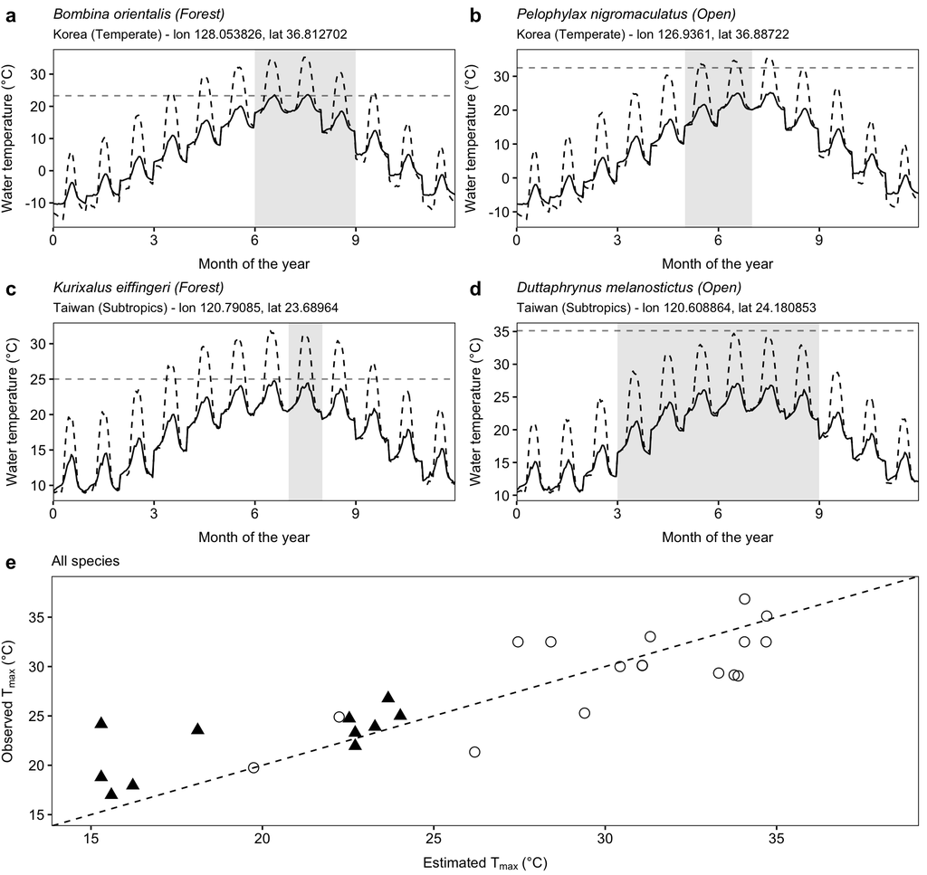

# 5 Relationship between CT<sub>max</sub>, T<sub>max</sub>, and warming tolerance

Run analysis looking at the relationship between (**a**) CT<sub>max</sub> and T<sub>max</sub> (CT<sub>max</sub>–T<sub>max</sub> model), (**b**) warming tolerance (WT) and T<sub>max</sub> (WT–T<sub>max</sub> model), and (**c**) WT and CT<sub>max</sub> (WT–CT<sub>max</sub> model).

```r
set.seed(10)

# Set priors
prior <- c(
  brms::prior(normal(0, 5), "b"), # mean of 0 and SD of 10 (wide distribution)
  brms::prior(student_t(3, 0, 10), "sd"), # class of random effect deviation to calculate - has to be positive (no negative SD)
  brms::prior(student_t(3, 0, 10), "sigma")) # residual SD parameter

# Run CTmax_Tmax_model
CTmax_Tmax_model <- brms::brm(CTmax ~ Tmax + habitat + lat + (1 | species) + (1 | gr(species_tree, cov = phylo)),
                              data    = clean_dat,
                              family  = gaussian,
                              data2   = list(phylo = phylo_cor),
                              prior   = prior,
                              iter    = 1e4, warmup = 5e3, cores = 4, chains = 4,
                              control = list(adapt_delta = 0.99, max_treedepth = 18))

# Run WT_Tmax_model
WT_Tmax_model <- brms::brm(WT ~ Tmax + habitat + lat + (1 | species) + (1 | gr(species_tree, cov = phylo)),
                           data    = clean_dat,
                           family  = gaussian,
                           data2   = list(phylo = phylo_cor),
                           prior   = prior,
                           iter    = 1e4, warmup = 5e3, cores = 4, chains = 4,
                           control = list(adapt_delta = 0.99, max_treedepth = 18))

# Run WT_CTmax_model (grouped by species because of co-correlation of Ctmax and WT with Tmax)
WT_CTmax_model <- brms::brm(WT_mean ~ CTmax_mean + habitat + lat + (1 | gr(species_tree, cov = phylo)),
                            data    = summary_dat,
                            family  = gaussian,
                            prior   = prior,
                            data2   = list(phylo = phylo_cor),
                            iter    = 1e4, warmup = 5e3, cores = 4, chains = 4,
                            control = list(adapt_delta = 0.99, max_treedepth = 18))
```

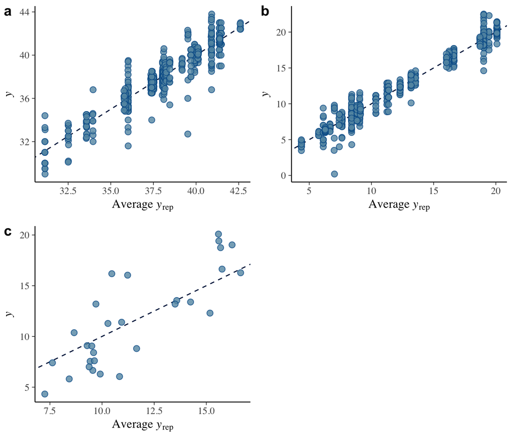

**Fig. S3.** Scatterplots of the observed data (y) vs the average simulated data (y<sub>rep</sub>) from the posterior predictive distribution for the (**a**) CT<sub>max</sub>–T<sub>max</sub> model, (**b**) WT–T<sub>max</sub> model, and (**c**) WT–CT<sub>max</sub> model. Dashed line represents a slope of 1.

## 5.1 Model output

### Table S4

**Table S4.** Point estimates and 95% credible intervals (as determined using Bayesian methods) for fitted parameters estimated for the correlation between CT<sub>max</sub> and T<sub>max</sub>, which includes fixed-effect parameters for $\beta_0$, the average across-species intercept; $\beta_1$, the average across-species slope of T<sub>max</sub>; habitat (closed and open habitat); and latitude. Group-level effects include the standard deviations (sd) for species-level variation in the intercept ($\Delta_{\beta_0[\zeta]}$), and phylogenetic variation in the intercept ($\Delta_{\beta_0[\phi]}$). Phylogenetic signal was calculated as $\lambda = \sigma_\phi^2 / (\sigma_\phi^2 + \sigma^2)$, where $\sigma_\phi^2$ is the estimated phylogenetic variance (i.e. sd$(\Delta_{\beta_0[\phi]})^2$).

| Parameter | Estimate | Est.Error | Q2.5 | Q97.5 |
| --- | --- | --- | --- | --- |
| **Fixed effects** |  |  |  |  |
| $\beta_0$ | 29.388 | 3.241 | 23.026 | 35.762 |
| T<sub>max</sub>, $\beta_1$ | 0.241 | 0.117 | 0.009 | 0.471 |
| Habitat - Open | 0.268 | 1.220 | -2.146 | 2.644 |
| Latitude | 0.081 | 0.065 | -0.048 | 0.210 |
| **Group-level effects** |  |  |  |  |
| sd$(\Delta_{\beta_0[\zeta]})$ | 2.086 | 0.504 | 1.011 | 3.064 |
| sd$(\Delta_{\beta_0[\phi]})$ | 1.812 | 1.409 | 0.066 | 5.277 |
| **Phylogenetic signal** |  |  |  |  |
| $\lambda$ | 0.580 | 0.311 | 0.004 | 0.961 |

### Table S5

**Table S5.** Point estimates and 95% credible intervals (as determined using Bayesian methods) for fitted parameters estimated for the correlation between warming tolerance and T<sub>max</sub>, which includes fixed-effect parameters for $\beta_0$, the average across-species intercept; $\beta_1$, the average across-species slope of T<sub>max</sub>; habitat (closed and open habitat); and latitude. Group-level effects include the standard deviations (sd) for species-level variation in the intercept ($\Delta_{\beta_0[\zeta]}$), and phylogenetic variation in the intercept ($\Delta_{\beta_0[\phi]}$). Phylogenetic signal was calculated as $\lambda = \sigma_\phi^2 / (\sigma_\phi^2 + \sigma^2)$, where $\sigma_\phi^2$ is the estimated phylogenetic variance (i.e. sd$(\Delta_{\beta_0[\phi]})^2$).

| Parameter | Estimate | Est.Error | Q2.5 | Q97.5 |
| --- | --- | --- | --- | --- |
| **Fixed effects** |  |  |  |  |
| $\beta_0$ | 29.445 | 3.334 | 22.853 | 36.016 |
| T<sub>max</sub>, $\beta_1$ | -0.761 | 0.117 | -0.992 | -0.531 |
| Habitat - Open | 0.303 | 1.236 | -2.140 | 2.752 |
| Latitude | 0.081 | 0.065 | -0.050 | 0.209 |
| **Group-level effects** |  |  |  |  |
| sd$(\Delta_{\beta_0[\zeta]})$ | 2.088 | 0.500 | 1.029 | 3.071 |
| sd$(\Delta_{\beta_0[\phi]})$ | 1.863 | 1.429 | 0.081 | 5.334 |
| **Phylogenetic signal** |  |  |  |  |
| $\lambda$ | 0.589 | 0.310 | 0.006 | 0.963 |

### Table S6

**Table S6.** Point estimates and 95% credible intervals (as determined using Bayesian methods) for fitted parameters estimated for the correlation between warming tolerance and CT<sub>max</sub> at the species level, which includes fixed-effect parameters for $\beta_0$, the average across-species intercept; $\beta_1$, the average across-species slope of CT<sub>max</sub>; habitat (closed and open habitat); and latitude. Group-level effects include the standard deviations (sd) for phylogenetic variation in the intercept ($\Delta_{\beta_0[\phi]}$). Phylogenetic signal was calculated as $\lambda = \sigma_\phi^2 / (\sigma_\phi^2 + \sigma^2)$, where $\sigma_\phi^2$ is the estimated phylogenetic variance (i.e. sd$(\Delta_{\beta_0[\phi]})^2$).

| Parameter | Estimate | Est.Error | Q2.5 | Q97.5 |
| --- | --- | --- | --- | --- |
| **Fixed effects** |  |  |  |  |
| $\beta_0$ | 4.957 | 12.022 | -18.649 | 28.594 |
| CT<sub>max</sub>, $\beta_1$ | 0.278 | 0.336 | -0.384 | 0.933 |
| Habitat - Open | -5.589 | 1.611 | -8.700 | -2.343 |
| Latitude | -0.028 | 0.120 | -0.262 | 0.213 |
| **Group-level effect** |  |  |  |  |
| sd$(\Delta_{\beta_0[\phi]})$ | 3.240 | 2.162 | 0.175 | 8.526 |
| **Phylogenetic signal** |  |  |  |  |
| $\lambda$ | 0.416 | 0.289 | 0.002 | 0.947 |

# 6 Habitat and region analysis

Run analysis looking at the relationship between (**a**) CT<sub>max</sub> and (**b**) warming tolerance (WT) between habitat (closed-forest and open) and region (subtropic and temperate).

```r
CTmax_model <- brms::brm(CTmax ~ habitat + region + (1 | species) + (1 | gr(species_tree, cov = phylo)),
                         data    = clean_dat,
                         family  = gaussian,
                         data2   = list(phylo = phylo_cor),
                         prior   = prior,
                         iter    = 1e4, warmup = 5e3, cores = 4, chains = 4,
                         control = list(adapt_delta = 0.99, max_treedepth = 18))

WT_model <- brms::brm(WT ~ habitat * region + (1 | species) + (1 | gr(species_tree, cov = phylo)),
                      data    = clean_dat,
                      family  = gaussian,
                      data2   = list(phylo = phylo_cor),
                      prior   = prior,
                      iter    = 1e4, warmup = 5e3, cores = 4, chains = 4,
                      control = list(adapt_delta = 0.99, max_treedepth = 18))

WT_lat_model <- brms::brm(WT ~ lat * habitat + (1 | species) + (1 | gr(species_tree, cov = phylo)),
                      data    = clean_dat,
                      family  = gaussian,
                      data2   = list(phylo = phylo_cor),
                      prior   = prior,
                      iter    = 1e4, warmup = 5e3, cores = 4, chains = 4,
                      control = list(adapt_delta = 0.99, max_treedepth = 18))
```

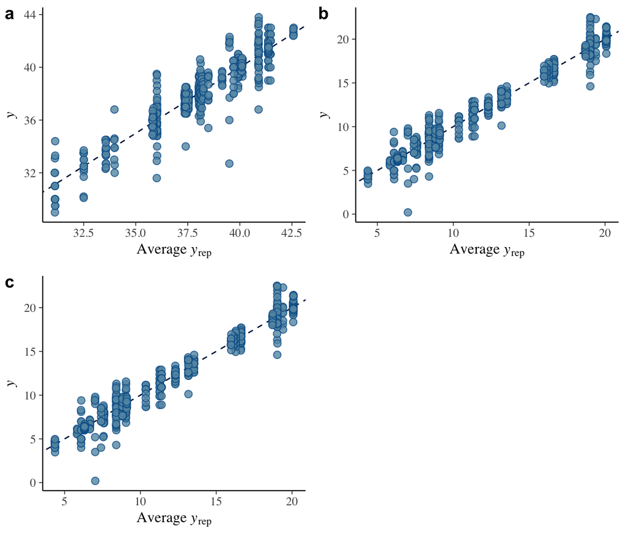

**Fig. S4.** Scatterplots of the observed data (y) vs the average simulated data (y<sub>rep</sub>) from the posterior predictive distribution for the (**a**) CT<sub>max</sub> model, (**b**) WT model, and (**c**) WT–latitude model. Dashed line represents a slope of 1.

## Model output

### Table S7

**Table S7.** Point estimates and 95% credible intervals (as determined using Bayesian methods) for fitted parameters estimated for the relationship between CT<sub>max</sub> with habitat and region, which includes fixed-effect parameters for $\beta_0$, the average across-species intercept; habitat (closed and open habitat); and region (subtropics, temperate). Group-level effects include the standard deviations (sd) for species-level variation in the intercept ($\Delta_{\beta_0[\zeta]}$), and phylogenetic variation in the intercept ($\Delta_{\beta_0[\phi]}$). Phylogenetic signal was calculated as $\lambda = \sigma_\phi^2 / (\sigma_\phi^2 + \sigma^2)$, where $\sigma_\phi^2$ is the estimated phylogenetic variance (i.e. sd$(\Delta_{\beta_0[\phi]})^2$).

| Parameter | Estimate | Est.Error | Q2.5 | Q97.5 |
| --- | --- | --- | --- | --- |
| **Fixed effects** |  |  |  |  |
| $\beta_0$ | 36.548 | 1.378 | 33.888 | 39.434 |
| Habitat - Open | 2.133 | 0.928 | 0.321 | 3.963 |
| Region - Temperate | 1.688 | 0.987 | -0.272 | 3.611 |
| **Group-level effects** |  |  |  |  |
| sd$(\Delta_{\beta_0[\zeta]})$ | 2.105 | 0.519 | 1.075 | 3.141 |
| sd$(\Delta_{\beta_0[\phi]})$ | 2.264 | 1.394 | 0.203 | 5.527 |
| **Phylogenetic signal** |  |  |  |  |
| $\lambda$ | 0.697 | 0.258 | 0.036 | 0.965 |

### Table S8

| Parameter | Estimate | Est.Error | Q2.5 | Q97.5 |
| --- | --- | --- | --- | --- |
| **Fixed effects** |  |  |  |  |
| $\beta_0$ | 13.087 | 1.773 | 9.685 | 16.783 |
| Habitat - Open | -3.005 | 1.524 | -6.064 | -0.011 |
| Region - Temperate | 3.756 | 1.920 | -0.142 | 7.410 |
| Habitat - Open: Region - Temperate | -6.241 | 2.349 | -10.699 | -1.529 |
| **Group-level effects** |  |  |  |  |
| sd$(\Delta_{\beta_0[\zeta]})$ | 3.184 | 0.603 | 2.072 | 4.453 |
| sd$(\Delta_{\beta_0[\phi]})$ | 2.102 | 1.644 | 0.083 | 6.297 |
| **Phylogenetic signal** |  |  |  |  |
| $\lambda$ | 0.625 | 0.307 | 0.006 | 0.973 |

# 7 Warming and deforesation analysis

Run analysis looking at the relationship between climate (current and warming), with the interaction between category (open and shaded simulated habitat), habitat (closed and open habitat - breeding) and region (subtropics, temperate) on warming tolerance.

```r
# Calculate WT
proj_data <- proj_data %>%
  dplyr::mutate(WT_shade_cur = CTmax_mean - est_Tmax_shade,
                WT_open_cur  = CTmax_mean - est_Tmax_open,
                WT_shade_4C  = CTmax_mean - est_Tmax_shade_4C,
                WT_open_4C   = CTmax_mean - est_Tmax_open_4C)

# Convert wide to long format
proj_long <- proj_data %>%
  dplyr::select(region, species, CTmax_mean, habitat, lat, WT_shade_cur, WT_open_cur, WT_shade_4C, WT_open_4C) %>%
  tidyr::pivot_longer(!c(region, species, CTmax_mean, habitat, lat), names_to = "category", values_to = "values") %>%
  dplyr::mutate(climate = case_when(endsWith(category, "cur") ~ "Current",
                                    endsWith(category, "4C")~ "Warming"),
                category = dplyr::recode(category,
                                         WT_open_cur = "Open habitat",
                                         WT_shade_cur = "Shaded habitat",
                                         WT_open_4C = "Open habitat",
                                         WT_shade_4C = "Shaded habitat"))

# Add phylogeny to dataset
proj_long$species_tree <- summary_dat$species_tree[match(proj_long$species, summary_dat$species)]

# Run brms model
proj_model <- brms::brm(values ~ climate + category * habitat * region + (1 | species) + (1 | gr(species_tree, cov = phylo)),
                        data    = proj_long,
                        family  = gaussian,
                        data2   = list(phylo = phylo_cor),
                        iter    = 1e4, warmup = 5e3, cores = 4, chains = 4,
                        control = list(adapt_delta = 0.99, max_treedepth = 18))
```

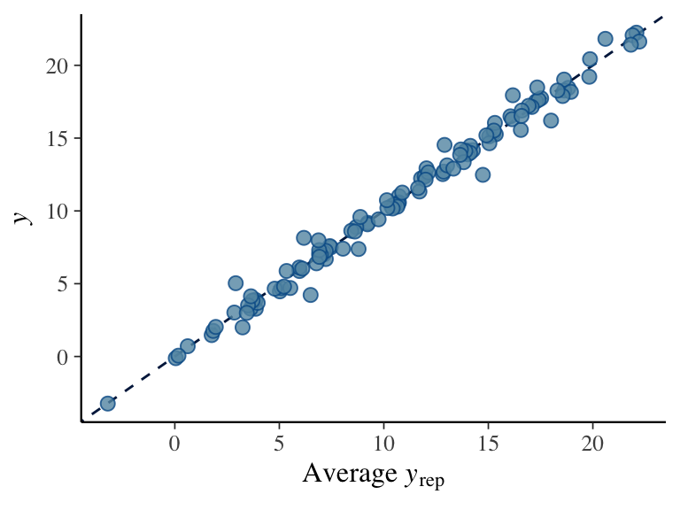

**Fig. S5.** Scatterplot of the observed data (y) vs the average simulated data (yrep) from the posterior predictive distribution for the climate and deforestation projection model. Dashed line represents a slope of 1.

## 7.1 Model output

**Table S9.** Point estimates and 95% credible intervals (as determined using Bayesian methods) for fitted parameters estimated for the relationship between warming tolerance with climate change and deforestation, which includes fixed-effect parameters for $\beta_0$, the average across-species intercept; climate (current, warming); and the three-way interaction with shaded (open and shaded simulated habitat), habitat (closed and open habitat - breeding) and region (subtropics, temperate). Group-level effects include the standard deviations (sd) for species-level variation in the intercept ($\Delta_{\beta_0[\zeta]}$), and phylogenetic variation in the intercept ($\Delta_{\beta_0[\phi]}$). Phylogenetic signal was calculated as $\lambda = \sigma_\phi^2 / (\sigma_\phi^2 + \sigma^2)$, where $\sigma_\phi^2$ is the estimated phylogenetic variance (i.e. sd$(\Delta_{\beta_0[\phi]})^2$).

| Parameter | Estimate | Est.Error | Q2.5 | Q97.5 |
| --- | --- | --- | --- | --- |
| **Fixed effects** |  |  |  |  |
| $\beta_0$ | 9.097 | 2.239 | 4.688 | 13.798 |
| Climate - Warming | -3.266 | 0.145 | -3.554 | -2.983 |
| Shaded | 6.845 | 0.292 | 6.266 | 7.412 |
| Habitat - Open | -0.072 | 1.863 | -3.681 | 3.610 |
| Region - Temperate | -3.538 | 2.552 | -8.637 | 1.472 |
| Shaded: Habitat - Open | 0.068 | 0.375 | -0.656 | 0.803 |
| Shaded: Region - Temperate | 4.977 | 0.452 | 4.098 | 5.856 |
| Habitat - Open: Region - Temperate | 2.713 | 3.232 | -3.559 | 9.076 |
| Shaded: Habitat - Open: Region - Temperate | -2.206 | 0.597 | -3.376 | -1.036 |
| **Group-level effects** |  |  |  |  |
| sd$(\Delta_{\beta_0[\zeta]})$ | 3.333 | 0.855 | 1.286 | 4.901 |
| sd$(\Delta_{\beta_0[\phi]})$ | 2.793 | 2.390 | 0.091 | 8.739 |
| **Phylogenetic signal** |  |  |  |  |
| $\lambda$ | 0.735 | 0.302 | 0.014 | 0.992 |

# 8 Figures for main text

Raw figures produced were modified in [Adobe Illustrator](https://www.adobe.com/au/products/illustrator.html) for publication.

## 8.1 Figure 2 - CT<sub>max</sub>, T<sub>max</sub>, warming tolerance relationship

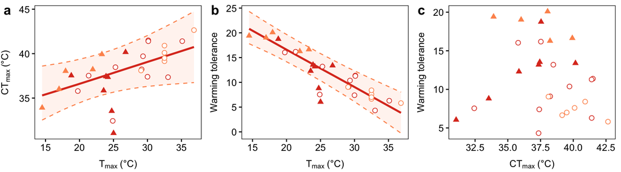

```r
# Extract marginal effects
CTmax_Tmax_me <- as.data.frame(ggeffects::ggpredict(CTmax_Tmax_model, terms = c("Tmax[sample = 25]")))
WT_Tmax_me    <- as.data.frame(ggeffects::ggpredict(WT_Tmax_model, terms = c("Tmax[sample = 25]")))

# Fig 2
ctmax_tmax_plot <- summary_dat %>%
  ggplot() +
  geom_ribbon(data = CTmax_Tmax_me, aes(x = x, ymin = conf.low, ymax = conf.high), fill = "#FE945C",alpha = 0.1) +
  geom_line(data = CTmax_Tmax_me, aes(x = x, y = conf.low), colour = "#FE945C", linetype = "dashed") +
  geom_line(data = CTmax_Tmax_me, aes(x = x, y = conf.high), colour = "#FE945C", linetype = "dashed") +
  geom_line(data = CTmax_Tmax_me, aes(x = x, y = predicted), colour = "#DD3B24", size = 1) +
  geom_point(aes(x = Tmax, y = CTmax_mean, colour = region, shape = habitat), size = 2, fill = "white") +
  scale_shape_manual(values = c(17, 21)) +
  scale_colour_manual(values = c("#DD3B24", "#FE945C")) +
  xlab(expression(T["max"]~"(°C)")) +
  ylab(expression("CT"["max"]~"(°C)")) +
  mytheme()

wt_tmax_plot <- summary_dat %>%
  ggplot() +
  geom_ribbon(data = WT_Tmax_me, aes(x = x, ymin = conf.low, ymax = conf.high), fill = "#FE945C",alpha = 0.1) +
  geom_line(data = WT_Tmax_me, aes(x = x, y = conf.low), colour = "#FE945C", linetype = "dashed") +
  geom_line(data = WT_Tmax_me, aes(x = x, y = conf.high), colour = "#FE945C", linetype = "dashed") +
  geom_line(data = WT_Tmax_me, aes(x = x, y = predicted), colour = "#DD3B24", size = 1) +
  geom_point(aes(x = Tmax, y = WT_mean, colour = region, shape = habitat), size = 2, fill = "white") +
  scale_shape_manual(values = c(17, 21)) +
  scale_colour_manual(values = c("#DD3B24", "#FE945C")) +
  xlab(expression(T['max']~"(°C)")) +
  ylab("Warming tolerance") +
  mytheme()

wt_ctmax_plot <- summary_dat %>%
  ggplot() +
  geom_point(aes(x = CTmax_mean, y = WT_mean, colour = region, shape = habitat), size = 2, fill = "white") +
  scale_shape_manual(values = c(17, 21)) +
  scale_colour_manual(values = c("#DD3B24", "#FE945C")) +
  xlab(expression(CT['max']~"(°C)")) +
  ylab("Warming tolerance") +
  mytheme()

cowplot::plot_grid(ctmax_tmax_plot + theme(legend.position = "none"),
                   wt_tmax_plot + theme(legend.position = "none"),
                   wt_ctmax_plot + theme(legend.position = "none"),
                   ncol = 3, align = "hv", axis = "tblr", labels = c("a", "b", "c"))
```

## 8.2 Figure 3 - CT<sub>max</sub> and warming tolerance across habitat and region

Latitude as category (**Fig. 3a and 3b**)

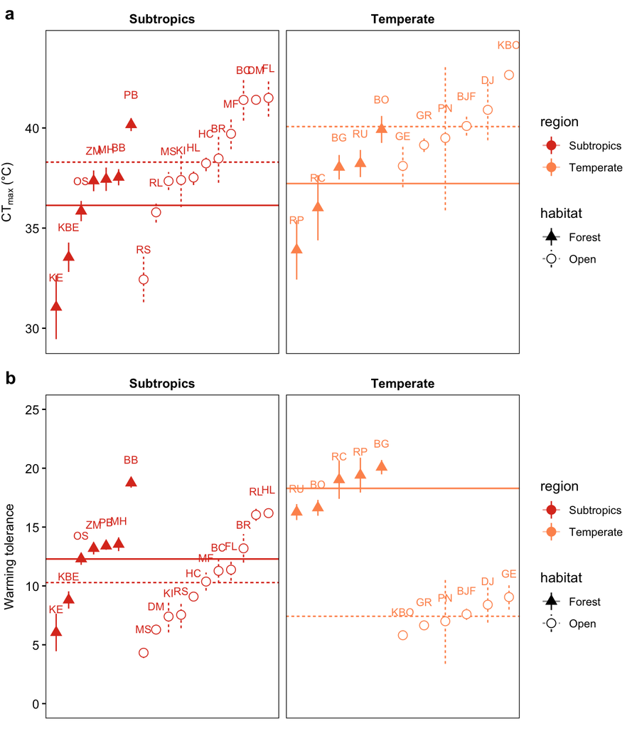

```r
# Fig 3 production
CTmax_plot <- summary_dat %>%
  # regrouping
  dplyr::group_by(region) %>%
  dplyr::arrange(habitat, CTmax_mean) %>%
  mutate(x = row_number()) %>% # change to number to order by habitat and CTmax
  ungroup() %>%
  # plotting
  ggplot(aes(x = x, y = CTmax_mean, colour = region, shape = habitat, label = sp_abbr)) +
  stat_mean_line(aes(linetype = habitat),  alpha = 0.5) +
  geom_pointrange(aes(ymin = CTmax_mean - CTmax_SD, ymax = CTmax_mean + CTmax_SD, linetype = habitat)) +
  geom_point(size = 3, fill = "white") +
  scale_shape_manual(values = c(17, 21)) +
  scale_colour_manual(values = c("#DD3B24", "#FE945C")) +
  geom_text(nudge_y = 1.5, size = 3, show.legend = FALSE) +
  xlab(NULL) +
  ylab(expression("CT"["max"]~"(°C)")) +
  facet_grid(. ~ region, scales = 'free_x') +
  mytheme() +
  theme(axis.title.x = element_blank(),
        axis.text.x  = element_blank(),
        axis.ticks.x = element_blank())

WT_plot <- summary_dat %>%
  # regrouping
  dplyr::group_by(region) %>%
  dplyr::arrange(habitat, WT_mean) %>%
  mutate(x = row_number()) %>% # change to number to order by habitat and WT
  ungroup() %>%
  # plotting
  ggplot(aes(x = x, y = WT_mean, colour = region, shape = habitat, label = sp_abbr)) +
  stat_mean_line(aes(linetype = habitat), alpha = 0.5) +
  geom_pointrange(aes(ymin = WT_mean - WT_SD, ymax = WT_mean + WT_SD, linetype = habitat)) +
  geom_point(size = 3, fill = "white") +
  scale_shape_manual(values = c(17, 21)) +
  scale_colour_manual(values = c("#DD3B24", "#FE945C")) +
  geom_text(nudge_y = 2, size = 3, show.legend = FALSE) +
  ylim(0, 25) +
  xlab("Species") +
  ylab("Warming tolerance") +
  facet_grid(. ~ region, scales = 'free_x') +
  mytheme() +
  theme(axis.title.x = element_blank(),
        axis.text.x  = element_blank(),
        axis.ticks.x = element_blank())

cowplot::plot_grid(CTmax_plot, WT_plot, nrow = 2, align = "hv", axis = "tblr", labels = c("a", "b"))
```

Latitude as continuous (**Fig. 3c**)

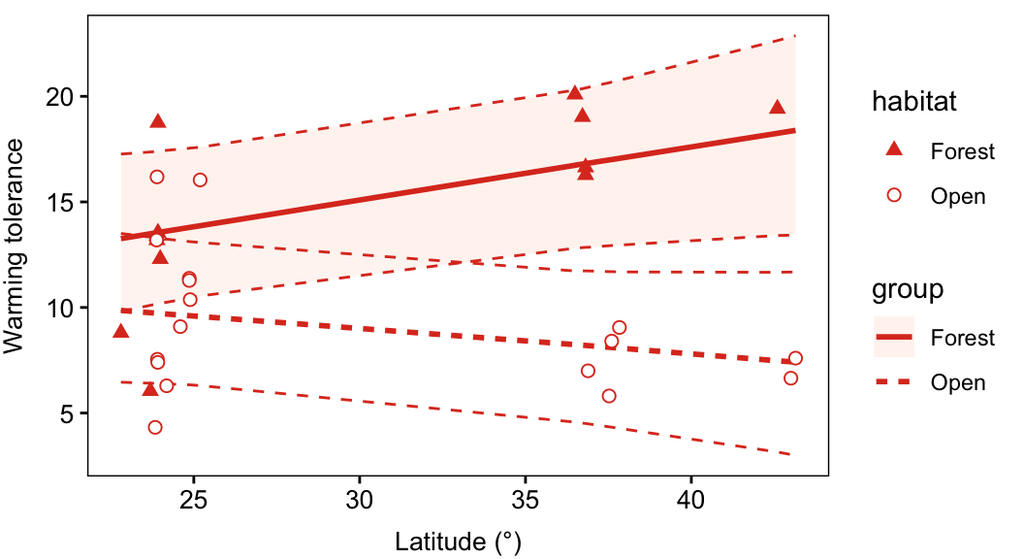

```r
WT_lat_me <- as.data.frame(ggeffects::ggpredict(WT_lat_model, terms = c("lat [sample = 26]", "habitat")))

summary_dat %>%
  ggplot() +
  geom_ribbon(data = WT_lat_me, aes(x = x, ymin = conf.low, ymax = conf.high, fill = group), alpha = 0.1) +
  geom_line(data = WT_lat_me, aes(x = x, y = conf.low, group = group), colour = "#DD3B24", linetype = "dashed") +
  geom_line(data = WT_lat_me, aes(x = x, y = conf.high, group = group), colour = "#DD3B24", linetype = "dashed") +
  geom_line(data = WT_lat_me, aes(x = x, y = predicted, linetype = group), colour = "#DD3B24", size = 1) +
  geom_point(aes(x = lat, y = WT_mean, shape = habitat), colour = "#DD3B24", size = 2, fill = "white") +
  scale_shape_manual(values = c(17, 21)) +
  scale_fill_manual(values = c("#FE945C", "white")) +
  xlab("Latitude (°)") +
  ylab("Warming tolerance") +
  mytheme()
```

## 8.3 Figure 4 - Warming and deforestation projection

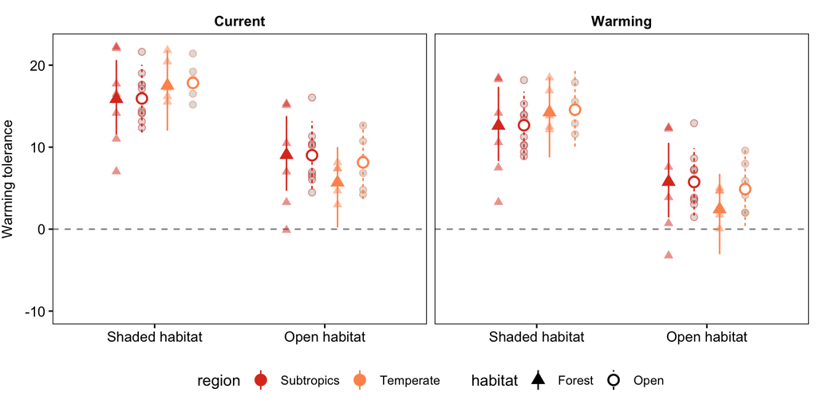

```r
# Extract estimate +/- 95% CI
conditions <- make_conditions(proj_model, c("climate", "region"))
predict_me <- brms::conditional_effects(proj_model, "category:habitat", conditions = conditions)
predict_dat <- as.data.frame(predict_me[[1]]) %>% dplyr::rename(estimate = estimate__, ci.lb = lower__, ci.ub = upper__)

proj_long %>%
  dplyr::mutate(category = forcats::fct_relevel(as.factor(category),"Shaded habitat", "Open habitat")) %>%
  ggplot() +
  geom_hline(yintercept = 0, linetype = "dashed", alpha = 0.5) +
  geom_point(aes(x = category, y = values, colour = region, shape = habitat), size = 2, position = position_dodge(0.6), fill = "grey", alpha = 0.5) +
  geom_pointrange(data = predict_dat, aes(x = category, y = estimate, ymin = ci.lb, ymax = ci.ub, colour = region, shape = habitat, linetype = habitat),
                  position = position_dodge(0.6), size = 0.7, fill = "white") +
  ylab("Warming tolerance") + xlab(NULL) +
  scale_shape_manual(values = c(17, 21)) +
  scale_colour_manual(values = c("#DD3B24", "#FE945C")) +
  scale_fill_manual(values = c("#DD3B24", "#FE945C")) +
  ylim(-10, max(proj_long$values)) +
  facet_grid(. ~ climate) +
  mytheme() +
  theme(legend.position = "bottom")
```

# 9 [20/01/2023 CORRECTION] Microclimate models and future scenario

The `micro_global` function did not have the soil moisture function on by default. After consultation with the *NicheMapR* developer Michael Kearney, we re-estimated the pond temperatures using the `micro_era5` function which provides fine-scale resolution (~1 km weather model forecast.

The model does not confirm that pond drying will ‘not occur’ as stated in the main text. However, the higher rain multiplier (`rainmult`) reduces the likelihood of pond drying.

The equations from the **Pond thermodynamic model** do not apply to the *NicheMapR* models. We followed the methods from Enriquez-Urzelai et al. (2019) to estimate pond temperature.

## 9.1 Download microclimate spatial map

Download the `mcera5` microclimate data to a local directory to run the `micro_era5` function faster.

```r
# get ERA5 data with package mcera5
# assign your credentials (register here: https://cds.climate.copernicus.eu/user/register)
uid         <- "$$$$$$"
cds_api_key <- "$$$$$$$$-$$$$-$$$$-$$$$-$$$$$$$$$$$$"
ecmwfr::wf_set_key(user = uid, key = cds_api_key, service = "cds")

# bounding coordinates (in WGS84 / EPSG:4326)
xmn <- min(summary_dat$lon) - 1
xmx <- max(summary_dat$lon) + 1
ymn <- min(summary_dat$lat) - 1
ymx <- max(summary_dat$lat) + 1

# temporal extent
st_time <- lubridate::ymd("2013:01:01") # earliest sampling date
en_time <- lubridate::ymd("2020:12:31") # latest sampling date

# filename and location for downloaded .nc files
file_prefix <- "era5"
op <- "YOUR DIRECTORY"

# build a request (covering multiple years)
req <- mcera5::build_era5_request(xmin = xmn, xmax = xmx,
                          ymin = ymn, ymax = ymx,
                          start_time   = st_time,
                          end_time     = en_time,
                          outfile_name = file_prefix)

mcera5::request_era5(request = req, uid = uid, out_path = op)
```

## 9.2 Simulate pond temperature

Run *NichemapR* to simulate pond temperatures under four hypothetical scenarios: (**a**) current climate with open habitat, (**b**) current climate with shaded habitat, (**c**) warming climate with open habitat, and (**d**) warming climate with shaded habitat. To ensure the pond does not dry up during the sampling period, we increased `rainmult` to 20.

```r
sum_dat <- as.data.frame(clean_dat %>%
  dplyr::group_by(region, country, habitat, family, species) %>%
  dplyr::summarise(lon        = mean(lon),
                   lat        = mean(lat),
                   Tmax       = mean(Tmax),
                   year_start = min(year_start),
                   year_end   = min(year_finish),
                   month_start = mean(month_start),
                   month_end   = mean(month_end)))

# Create loop for each coordinates
est_Tmax <- NULL
for( i in 1:nrow(sum_dat)){
  micro_out <-
    NicheMapR::micro_era5(loc = c(sum_dat$lon[i], sum_dat$lat[i]),
                          runshade = 1, minshade = 0, # shade parameters
                          PE = PE, BB = BB, BD = BD, KS = KS, rainmult = 20,
                          maxpool = maxpool, LAI = LAI, cap = cap, soilgrids = soilgrids, # soil parameters to simulate pool
                          warm = 0, # current climate
                          DEP = DEP,
                          dstart = paste("01/01/", sum_dat$year_start[i], sep =""),
                          dfinish = paste("31/12/", sum_dat$year_end[i], sep =""),
                          runmoist = 1,
                          spatial = '/Users/nicholaswu/Library/CloudStorage/OneDrive-WesternSydneyUniversity/NicheMapR/era5', # change to your location
                          save = 0)

  metout <- data.frame(micro_out$metout) %>% # extract soil parameters
  dplyr::mutate(dates = row_number() / 730) %>% # hours to month
  dplyr::filter(dates >= sum_dat$month_start[i] & dates <= sum_dat$month_end[i])

  # extract water temp in open habitat
    open <- data.frame(micro_out$soil) %>% # extract soil parameters
      dplyr::mutate(dates = row_number() / 730) %>% # hours to month
      merge(metout, by = "dates") %>%
      dplyr::filter(dates >= sum_dat$month_start[i] & dates <= sum_dat$month_end[i] & POOLDEP > 400) %>%
      dplyr::summarise(est_Tmax_open = max(D50cm))
  print(open)

  # extract water temp in shaded habitat
  closed <- data.frame(micro_out$shadsoil) %>% # extract soil parameters
      dplyr::mutate(dates = row_number() / 730) %>% # hours to month
      merge(metout, by = "dates") %>%
    dplyr::filter(dates >= sum_dat$month_start[i] & dates <= sum_dat$month_end[i] & POOLDEP > 400) %>%
    dplyr::summarise(est_Tmax_shade = max(D50cm))
  print(closed)
  results <- cbind(sum_dat$species[i], open, closed)
  est_Tmax <- rbind(est_Tmax, results)
}

est_Tmax_4C <- NULL
for( i in 1:nrow(sum_dat)){
  micro_out <-
    NicheMapR::micro_era5(loc = c(sum_dat$lon[i], sum_dat$lat[i]),
                          runshade = 1, minshade = 0, # shade parameters
                          PE = PE, BB = BB, BD = BD, KS = KS, rainmult = 20,
                          maxpool = maxpool, LAI = LAI, cap = cap, soilgrids = soilgrids, # soil parameters to simulate pool
                          warm = 4, # future climate
                          DEP = DEP,
                          dstart = paste("01/01/", sum_dat$year_start[i], sep =""),
                          dfinish = paste("31/12/", sum_dat$year_end[i], sep =""),
                          runmoist = 1,
                          spatial = '/Users/nicholaswu/Library/CloudStorage/OneDrive-WesternSydneyUniversity/NicheMapR/era5', # change to your location
                          save = 0)
  metout <- data.frame(micro_out$metout) %>% # extract soil parameters
  dplyr::mutate(dates = row_number() / 730) %>% # hours to month
  dplyr::filter(dates >= sum_dat$month_start[i] & dates <= sum_dat$month_end[i])

  # extract water temp in open habitat
    open <- data.frame(micro_out$soil) %>% # extract soil parameters
      dplyr::mutate(dates = row_number() / 730) %>% # hours to month
      merge(metout, by = "dates") %>%
      dplyr::filter(dates >= sum_dat$month_start[i] & dates <= sum_dat$month_end[i] & POOLDEP > 400) %>%
      dplyr::summarise(est_Tmax_open_4C = max(D50cm))
  print(open)
  # extract water temp in shaded habitat
  closed <- data.frame(micro_out$shadsoil) %>% # extract soil parameters
      dplyr::mutate(dates = row_number() / 730) %>% # hours to month
      merge(metout, by = "dates") %>%
    dplyr::filter(dates >= sum_dat$month_start[i] & dates <= sum_dat$month_end[i] & POOLDEP > 400) %>%
    dplyr::summarise(est_Tmax_shade_4C = max(D50cm))
  print(closed)
  results <- cbind(sum_dat$species[i], open, closed)
  est_Tmax_4C <- rbind(est_Tmax_4C, results)
}

proj_data <- cbind(summary_dat, est_Tmax[,2], est_Tmax[,3], est_Tmax_4C[,2], est_Tmax_4C[,3]) %>%
  dplyr::rename(est_Tmax_open = "est_Tmax[, 2]",
                est_Tmax_shade = "est_Tmax[, 3]",
                est_Tmax_open_4C = "est_Tmax_4C[, 2]",
                est_Tmax_shade_4C = "est_Tmax_4C[, 3]")
```

## 9.3 Verify predicted values

Predicted T<sub>max</sub> from the heat budget models were validated with a linear model (below) and visually in **Updated Fig. S2**.

```r
proj_test <- proj_data %>%
  mutate(est_Tmax_test = ifelse(habitat == "Forest", est_Tmax_shade, est_Tmax_open)) %>%
  filter_all(all_vars(!is.infinite(.)))

predict_obs_model <- lm(Tmax ~ est_Tmax_test, data = proj_test)

verify2    <- summary(predict_obs_model)$r.squared
model_mae2 <- Metrics::mae(proj_test$Tmax, predict(predict_obs_model))
```

[output not shown]

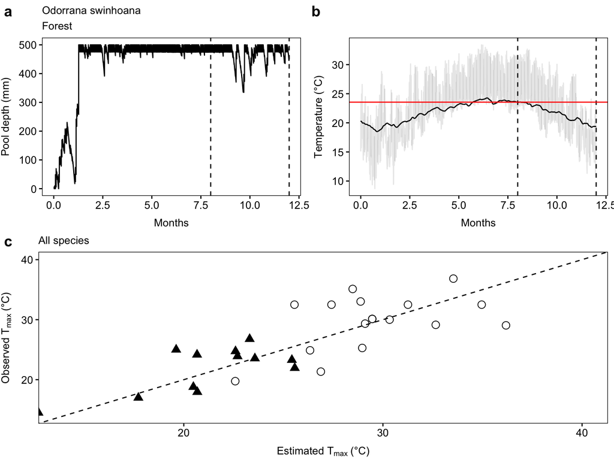

The updated estimated pond temperatures did not differ much relative to the original simulations.

# 10 References

**Ambu, J., Andersen, D. and Borzée, A.** (2022). [Spawning site selection and segregation at the landscape, habitat and microhabitat scales for five syntopic asian amphibians](https://doi.org/10.1163/15685381-bja10090). *Amphibia-Reptilia* **43**, 169–180.

**Chang, Y., Tseng, W., Chen, C., Huang, C., Chen, Y. and Hatch, K.** (2014). [Winter breeding and high tadpole densities may benefit the growth and development of tadpoles in a subtropical lowland treefrog](https://doi.org/0.1111/jzo.12162). *Journal of Zoology* **294**, 154–160.

**Hou, W.-S., Chang, Y.-H. and Wang, H.-W.** (2008). [Climatic effects and impacts of lakeshore bank designs on the activity of *Chirixalus idiootocus* in Yilan, Taiwan](https://doi.org/10.1016/j.ecoleng.2007.09.004). *Ecological Engineering* **32**, 52–59.

**Hsu, J.-L., Kam, Y.-C. and Fellers, G. M.** (2012). [Overwintering tadpoles and loss of fitness correlates in *Polypedates braueri* tadpoles that use artificial pools in a lowland agroecosystem](https://doi.org/0.1655/HERPETOLOGICA-D-11-00042.1). *Herpetologica* **68**, 184–194.

**Huang, W.-S., Lin, J.-Y. and Yu, J. Y.-L.** (1996). The male reproductive cycle of the toad, *Bufo bankorensis*, in Taiwan. *Zoological Studies* **35**, 128–137.

**Huang, W.-S., Lin, J.-Y. and Yu, J. Y.-L.** (1997). [Male reproductive cycle of the toad *Bufo melanostictus* in Taiwan](https://doi.org/10.2108/zsj.14.497). *Zoological Science* **14**, 497–503.

**Huang, W.-S., Cheng, Y.-S. and Tu, H.-Y.** (2004). [Reproductive patterns of two sympatric ranid frogs, *Rana latouchii* and *R. sauteri*, with comments on anuran breeding seasons in Taiwan](https://doi.org/10.6693/CAR.2004.17.1). *Collection and Research* **17**, 1–10.

**Jang-Liaw, N.-H. and Lee, T.-H.** (2009). [Intraspecific relationships of populations of the brown frog *Rana sauteri* (Ranidae) on Taiwan, inferred from mitochondrial cytochrome b sequences](https://doi.org/10.2108/zsj.26.608). *Zoological Science* **26**, 608–616.

**Jung, Y. S., Park, M. O. and Koo, B. H.** (2013). [A substitute habitat planning for *Kaloula borealis* based on wetlands](https://doi.org/10.13087/kosert.2013.16.1.001). *Journal of the Korean Society of Environmental Restoration Technology* **16**, 1–15.

**Kam, Y.-C., Wang, C.-S. and Lin, Y.-S.** (1995). [Reproduction and diet of the brown frog *Rana longicrus* in Taiwan](https://doi.org/10.13087/kosert.2013.16.1.001). *Zoological Studies* **34**, 193–201.

**Kearney, M. R. and Porter, W. P.** (2017). [NicheMapR – an r package for biophysical modelling: The microclimate model](https://doi.org/10.1111/ecog.02360). *Ecography* **40**, 664–674.

**Kuan, S. and Lin, Y.** (2011). [Bigger or faster? Spring and summer tadpole cohorts use different life‐history strategies](https://doi.org/10.1111/j.1469-7998.2011.00836.x). *Journal of Zoology* **285**, 165–171.

**Lai, Y., Shieh, B. and Kam, Y.** (2007). [Population patterns of a riparian frog (*Rana swinhoana*) before and after an earthquake in subtropical Taiwan](https://doi.org/10.1111/j.1744-7429.2007.00320.x). *Biotropica* **39**, 731–736.

**Lin, Y.-S. and Kam, Y.-C.** (2008). Nest choice and breeding phenology of an arboreal-breeding frog, *Kurixalus eiffingeri* (Rhacophoridae), in a bamboo forest. *Zoological Studies* **47**, 129.

**Lin, H.-D., Chen, Y.-R. and Lin, S.-M.** (2012). [Strict consistency between genetic and topographic landscapes of the brown tree frog (*Buergeria robusta*) in Taiwan](https://doi.org/10.1016/j.ympev.2011.09.022). *Molecular Phylogenetics and Evolution* **62**, 251–262.

**Matsui, M. and Maeda, N.** (2018). *Encyclopedia of japanese frogs Japan book*. Japan: Bun-ichiSogo Shuppan.

**Mitchell, N., Hipsey, M. R., Arnall, S., McGrath, G., Tareque, H. B., Kuchling, G., Vogwill, R., Sivapalan, M., Porter, W. P. and Kearney, M. R.** (2012). [Linking eco-energetics and eco-hydrology to select sites for the assisted colonization of australia’s rarest reptile](https://doi.org/10.3390/biology2010001). *Biology* **2**, 1–25.

**Othman, S. N., Litvinchuk, S. N., Maslova, I., Dahn, H., Messenger, K. R., Andersen, D., Jowers, M. J., Kojima, Y., Skorinov, D. V. and Yasumiba, K.** (2022). [From Gondwana to the Yellow sea, evolutionary diversifications of true toads *Bufo* sp. In the Eastern Palearctic and a revisit of species boundaries for Asian lineages](https://doi.org/10.7554/eLife.70494). *Elife* **11**, e70494.

**Roh, G., Borzée, A. and Jang, Y.** (2014). [Spatiotemporal distributions and habitat characteristics of the endangered treefrog, *Hyla suweonensis*, in relation to sympatric *H. japonica*](https://doi.org/j.ecoinf.2014.07.009). *Ecological Informatics* **24**, 78–84.

**Tominaga, A., Matsui, M., Eto, K. and Ota, H.** (2015). [Phylogeny and differentiation of wide-ranging Ryukyu Kajika frog *Buergeria japonica* (Amphibia: Rhacophoridae): Geographic genetic pattern not simply explained by vicariance through strait formation](https://doi.org/10.2108/zs140227). *Zoological Science* **32**, 240–247.

**Wu, S.-P., Huang, C.-C., Tsai, C.-L., Lin, T.-E., Jhang, J.-J. and Wu, S.-H.** (2016). [Systematic revision of the Taiwanese genus Kurixalus members with a description of two new endemic species (Anura, Rhacophoridae)](https://doi.org/10.3897/zookeys.557.6131). *ZooKeys* 121.

**Yang, S. Y., Kim, J. B., Min, M. S., Suh, J. H. and Kang, Y. J.** (2001). *Monograph of Korean Amphibia*. Seoul, Republic of Korea: Academy book Press.

**Yoo, N., Do, M. S., Nam, H.-K., Choi, G., Son, S.-J. and Yoo, J.-C.** (2019). [Habitat characteristics of anuran species inhabiting rice fields of western mid-south Korea - In the case of Daeho reclamation agricultural land by farming practices](https://doi.org/10.11614/KSL.2019.52.4.366). *Korean Journal of Ecology and Environment* **52**, 366–377.

## 10.1 Session Information

**R version 4.2.2 (2022-10-31)**

**Platform:** aarch64-apple-darwin20 (64-bit)

**attached base packages:** *stats*, *graphics*, *grDevices*, *utils*, *datasets*, *methods* and *base*

**other attached packages:** *microclima(v.0.1.0)*, *RNetCDF(v.2.6-1)*, *mcera5(v.0.3.0)*, *raster(v.3.6-13)*, *sp(v.1.5-1)*, *pander(v.0.6.5)*, *NicheMapR(v.3.2.1)*, *diversitree(v.0.9-16)*, *phytools(v.1.2-0)*, *maps(v.3.4.1)*, *ape(v.5.6-2)*, *rstan(v.2.21.7)*, *StanHeaders(v.2.21.0-7)*, *brms(v.2.18.0)*, *Rcpp(v.1.0.9)*, *colorspace(v.2.0-3)*, *forcats(v.0.5.2)*, *stringr(v.1.5.0)*, *dplyr(v.1.0.10)*, *purrr(v.1.0.1)*, *readr(v.2.1.3)*, *tidyr(v.1.2.1)*, *tibble(v.3.1.8)*, *tidyverse(v.1.3.2)*, *Matrix(v.1.5-1)*, *cowplot(v.1.1.1)*, *ggplot2(v.3.4.0)* and *knitr(v.1.41)*

[^1]: Hawkesbury Institute for the Environment, Western Sydney University, NSW 2753, Australia, nicholas.wu.nz@gmail.com
[^2]: I would like to thank J. Kong (Trinity College Dublin) for showing me the way of Rmarkdown.